# WGCNA

Sergio Martí

2022-12-15

# WGCNA

WGCNA = weighted correlation network analysis

“https://horvath.genetics.ucla.edu/html/CoexpressionNetwork/Rpackages/WGCNA/”

## Instalar librerías

### Prerequisitos

El paquete WGCNA requiere la instalación de los siguientes paquetes: stats, grDevices, utils, matrixStats (0.8.1 o superior), Hmisc, splines, foreach, doParallel, fastcluster, dynamicTreeCut, survival, paralelo, preprocessCore, GO.db, imputar, y Anotación Dbi

```r
#install.packages(c("matrixStats", "Hmisc", "splines", "foreach", "doParallel", "fastcluster", "dynamicTreeCut", "survival", "BiocManager"))

#BiocManager::install(c("GO.db", "preprocessCore", "impute"))
```

Si planea usar capacidades de anotación (como GOenrichmentAnalysis), también recomendamos instalar paquetes de anotación de Bioconductor.

```r
#orgCodes = c("Hs", "Mm", "Rn", "Pf", "Sc", "Dm", "Bt", "Ce", "Cf", "Dr", "Gg");
#orgExtensions = c(rep(".eg", 4), ".sgd", rep(".eg", 6));
#packageNames = paste("org.", orgCodes, orgExtensions, ".db", sep="");

#BiocManager::install(c("GO.db", "KEGG.db", "topGO", packageNames, "hgu133a.db", "hgu95av2.db", "annotate", "hgu133plus2.db", "SNPlocs.Hsapiens.dbSNP.20100427", "minet", "OrderedList"))
```

```r
#BiocManager::install("WGCNA")
```

## Preliminares

Antes de realizar el análisis, se asegura el directorio de trabajo y de linkar todas las funciones y variables del paquete WGCNA al entorno.

```r
# Directorio de trabajo
getwd()
```

```
## [1] "D:/Sergio/Luis Miguel repo/WGCNA"
```

```r
# Si no es correcto, cambiar el directorio de trabajo con esta instrucción:
# workingDir = "."
# setwd(workingDir); rm(workingDir)

# Cargar el paquete de WGCNA
library(WGCNA)
# Esta línea es importante para el análisis, no omitir:
options(stringsAsFactors = FALSE)

# El paquete WGCNA permite lanzar trabajo en varios hilos de ejecución. Aunque es una forma de completar un trabajo antes, RStudio da problemas con esta parte. Omitir
# enableWGCNAThreads()
```

## Cargar los datos

Se van a cargar los datos de expresión genética y la lista de genes que han superado el filtro del Fold Change y p-valor después del análisis de expresión diferencial. El primer dataframe se encuentra en forma de objeto serializado y la lista se encuentran en un excel.

```r
# Objeto con la información de los counts y los pacientes

# El objeto que contiene toda la información esta guardado como .RDS
txi <- readRDS("../import quant/txi.RDS")
# Trabajaremos con los counts
countData <- txi$counts

# No vamos a trabajar más con txi, así que como ocupa 35MB, lo elimino de la memoria
rm(txi)

# La matriz tiene, en los nombres de las muetras, un sufijo después de una barra baja, que es el "sample ID" que se utilizó para secuenciarlo en illumina. Para que no de problemas, se van a renombrar

# Elimino el sufijo "_Sxx" de los nombres de las columnas
lNewColnames <- unlist(strsplit(colnames(countData), "_"))[seq(1, 2 * ncol(countData), 2)]

# Asigno los nuevos nombres de las columnas a la matriz
colnames(countData) <- lNewColnames

# Muestro los primeros datos
# head(countData)

rm(lNewColnames)

# Mostramos los datos de expresión
dim(countData);head(countData)
```

```
## [1] 38244    28
```

```
##                        103     105     112     113     131     151     165
## ENSG00000000003.15 280.690 269.872 437.320 354.990 565.889 474.571 393.377
## ENSG00000000005.6    0.000   1.000   2.000   5.000  14.000   0.000   1.000
## ENSG00000000419.14 468.499 657.489 417.199 670.997 476.536 303.273 464.651
## ENSG00000000457.14 292.789 289.795 250.316 338.842 339.367 258.275 297.864
## ENSG00000000460.17 148.557 101.415 201.240 132.638 132.400 169.704 270.774
## ENSG00000000938.13  37.000  84.008  82.001  36.000  87.000 108.000  39.180
##                         17     171     177     188     201     203     210
## ENSG00000000003.15 537.758 248.298 295.417 678.890 518.671 377.485 602.191
## ENSG00000000005.6    4.000   1.000   0.000   0.000   0.000   0.000   1.000
## ENSG00000000419.14 353.991 540.465 459.604 386.604 494.334 247.871 623.557
## ENSG00000000457.14 259.594 223.485 276.667 319.040 335.244 197.801 352.266
## ENSG00000000460.17 159.832 141.252 192.590 143.592 247.313 121.909 272.588
## ENSG00000000938.13  82.001  37.000  49.000  38.000 103.999 114.000  57.000
##                        218      30      37       5      63      64      70
## ENSG00000000003.15 636.489 418.424 410.440 597.728 460.811 463.123 625.235
## ENSG00000000005.6    2.000   3.000   0.000   0.000   1.000   1.000   1.000
## ENSG00000000419.14 616.128 881.789 460.925 457.024 566.649 324.236 852.521
## ENSG00000000457.14 370.288 464.448 238.741 257.118 287.889 256.463 359.007
## ENSG00000000460.17 302.957 212.938 222.348 178.380 145.989 125.019 226.644
## ENSG00000000938.13  18.000  88.000  70.999 144.001  44.000  59.000 144.590
##                         77      78      80      83       88      95      98
## ENSG00000000003.15 438.495 425.433 250.667 416.714 3950.941 661.838 572.685
## ENSG00000000005.6    0.000   2.000   4.000   0.000   15.000   0.000   0.000
## ENSG00000000419.14 605.586 323.024 824.963 543.388 4038.405 825.350 526.198
## ENSG00000000457.14 313.623 232.061 315.194 242.842 2167.094 286.643 397.920
## ENSG00000000460.17 207.402 214.585 109.392 204.298 1210.723 161.989 267.191
## ENSG00000000938.13  69.000  91.030 244.000  47.001  277.017  92.343  77.000
```

```r
# ---------------------------

# Datos clínicos
# Leer los datos del excel
clinicalData <- readxl::read_excel("../datos clinicos/dfClinical.xlsx")

# Muestro los primeros datos
# head(clinicalData)

# Los datos de la matriz estan ordenados como si los números fuesen carácteres, por lo que voy a transformar la variable "Sample" del dataframe de los datos clínicos a carácter, y después lo ordenaré de menor a mayor
clinicalData$Samples <- as.character(clinicalData$Samples)
clinicalData <- clinicalData[order(clinicalData$Samples),]

# Elimino la columna del paciente 88 de la matriz "countData"
countData <- countData[,colnames(countData) != "88"]

# Elimino la fila del paciente 88 en los datos clinicos
clinicalData <- clinicalData[clinicalData$Samples != "88",]

# ---------------------------

# Hoja de excel con los genes resultantes del análisis de expresión diferencial
# passedGenes <-
dfPassedGenes <- readxl::read_excel("../Volcano Plot/DEGs.xlsx", sheet = "log2FC > 2")
# Mostramos los datos de la lista de genes
dim(dfPassedGenes);head(dfPassedGenes)
```

```
## [1] 1309    9
```

```
## # A tibble: 6 × 9
##   ...1     baseMean log2FoldChange lfcSE  stat  pvalue    padj `gen name` change
##   <chr>       <dbl>          <dbl> <dbl> <dbl>   <dbl>   <dbl> <chr>      <chr>
## 1 ENSG000…    117.           -2.32 0.746 -3.10 1.91e-3 3.29e-2 CYP26B1    repre…
## 2 ENSG000…    441.           -2.68 0.683 -3.92 8.89e-5 4.63e-3 CD38       repre…
## 3 ENSG000…    357.           -2.17 0.678 -3.19 1.40e-3 2.72e-2 CAMKK1     repre…
## 4 ENSG000…    310.            2.61 0.647  4.03 5.55e-5 3.34e-3 HSPB6      overe…
## 5 ENSG000…    175.            3.34 0.584  5.73 1.01e-8 7.85e-6 MCUB       overe…
## 6 ENSG000…     10.2           6.18 2.18   2.83 4.64e-3 5.55e-2 HOXA11     overe…
```

Ahora se van a seleccionar los datos de expresión de la lista de genes. Estos datos se van a guardar en forma de matriz. Para que la función “pickSoftThreshold” funcione correctamente, la matriz de debe de organizar de forma que las filas correspondan con las muestras y las columnas con los genes.

```r
# Obtenemos los genes que han pasado filtro, en forma de lista
lGenes <- dfPassedGenes[,1]
lGenes <- unlist(lGenes)

# Seleccionamos la lista de genes que pasan el filtro
mExpressionData <- countData[lGenes,]

# Cambiamos filas por columnas
mExpressionData <- t(mExpressionData)

# Mostramos la matriz
head(mExpressionData[c(1:3), c(1:3)])
```

```
##     ENSG00000003137.9 ENSG00000004468.13 ENSG00000004660.15
## 103           197.812            225.729           1616.054
## 105           411.332            117.063           3365.201
## 112            64.000            446.002            212.540
```

```r
# Eliminamos los objetos que ya no se van a utilizar
rm(lGenes, countData)
```

## Construcción automática de redes y identificación de modulos

Este paso es la base para los análisis con WGCNA.

### Construcción automática de la red y detección de módulos

```r
powers = c(c(1:10), seq(form = 12, to = 21, by = 2))
sft = pickSoftThreshold(mExpressionData, powerVector = powers, verbose = 5)
```

```
## pickSoftThreshold: will use block size 1309.
##  pickSoftThreshold: calculating connectivity for given powers...
##    ..working on genes 1 through 1309 of 1309
```

```
##    Power SFT.R.sq  slope truncated.R.sq mean.k. median.k. max.k.
## 1      1   0.0393  0.330          0.880  359.00   347.000  607.0
## 2      1   0.0393  0.330          0.880  359.00   347.000  607.0
## 3      2   0.3080 -0.463          0.743  151.00   131.000  344.0
## 4      3   0.6880 -0.789          0.641   82.40    62.700  234.0
## 5      3   0.6880 -0.789          0.641   82.40    62.700  234.0
## 6      4   0.6910 -0.959          0.613   53.70    34.800  184.0
## 7      5   0.7270 -0.993          0.715   39.20    22.800  158.0
## 8      5   0.7270 -0.993          0.715   39.20    22.800  158.0
## 9      6   0.7440 -0.986          0.773   30.90    14.800  142.0
## 10     7   0.7800 -0.979          0.833   25.50    10.400  132.0
## 11     7   0.7800 -0.979          0.833   25.50    10.400  132.0
## 12     8   0.8000 -0.969          0.860   21.70     7.480  124.0
## 13     9   0.8310 -0.994          0.902   18.90     5.490  118.0
## 14     9   0.8310 -0.994          0.902   18.90     5.490  118.0
## 15    10   0.8450 -0.983          0.915   16.70     4.260  112.0
## 16    11   0.8420 -0.976          0.912   15.00     3.350  107.0
## 17    13   0.8840 -0.990          0.925   12.30     2.050   98.0
## 18    15   0.8930 -0.971          0.949   10.40     1.370   90.5
## 19    17   0.8920 -0.973          0.949    8.99     0.948   84.0
## 20    19   0.9000 -0.974          0.953    7.86     0.706   78.6
## 21    21   0.9050 -0.973          0.955    6.95     0.504   73.9
```

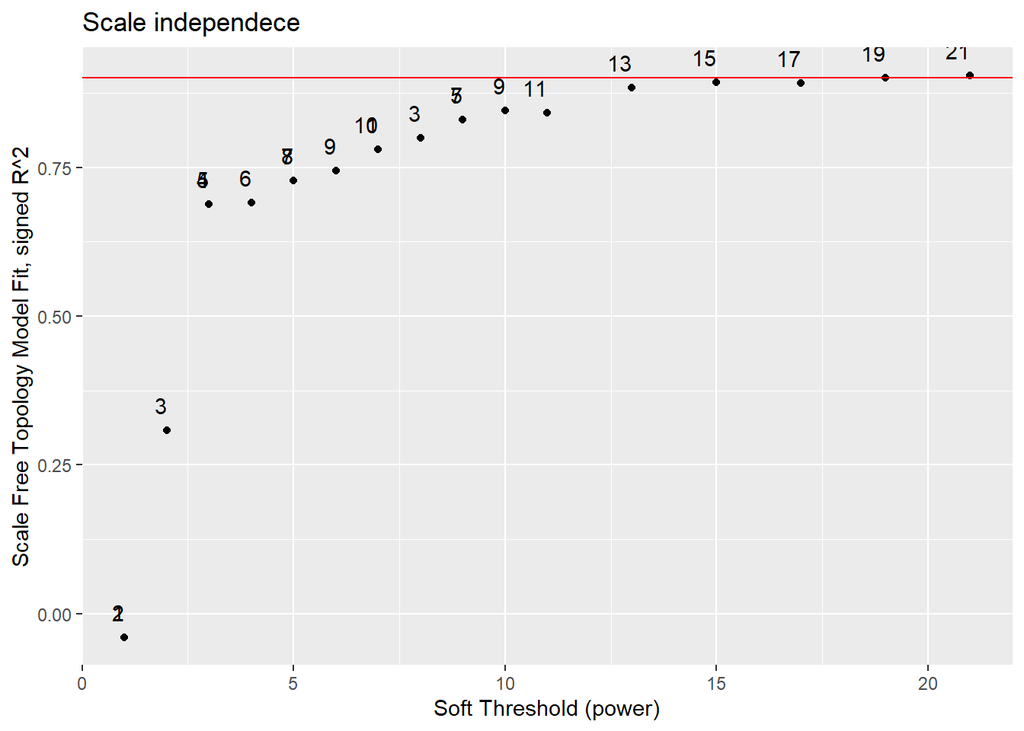

```r
dfToPlot <- data.frame(sft$fitIndices[,1], -sign(sft$fitIndices[,3])*sft$fitIndices[,2], powers)
colnames(dfToPlot) <- c("fitIndices", "sign", "powers")

ggplot2::ggplot(dfToPlot, ggplot2::aes(x = fitIndices, y = sign, label = powers)) +
  ggplot2::geom_point() +
  ggplot2::geom_text(hjust = 1, vjust = -1) +
  ggplot2::xlab("Soft Threshold (power)") +
  ggplot2::ylab("Scale Free Topology Model Fit, signed R^2") +
  ggplot2::ggtitle("Scale independece") +
  ggplot2::geom_hline(yintercept = 0.90, col = "red")
```

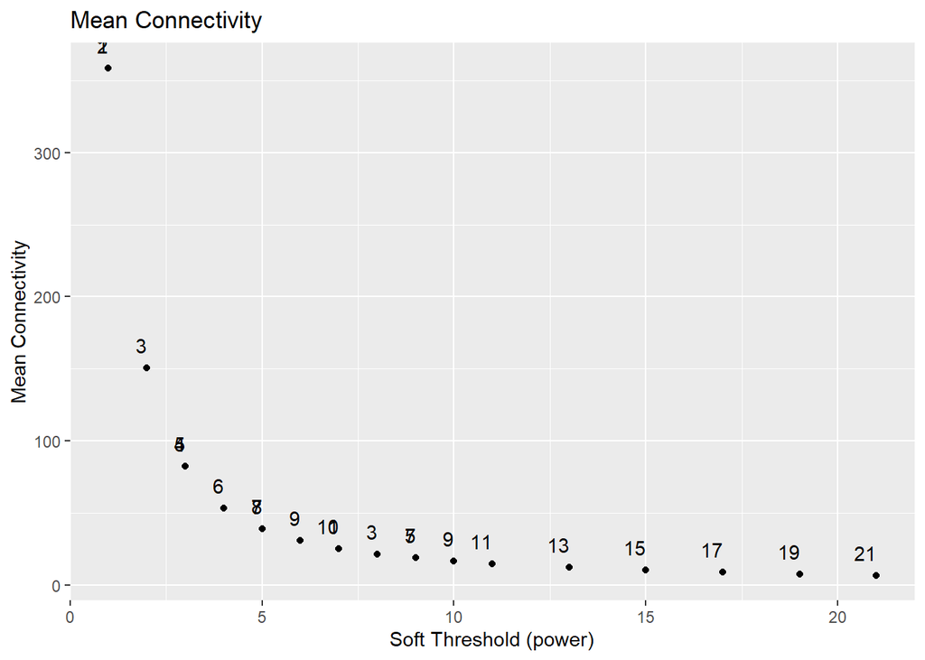

```r
dfToPlot <- data.frame(sft$fitIndices[,1], sft$fitIndices[,5], powers)
colnames(dfToPlot) <- c("fitIndices", "connectivity", "powers")

ggplot2::ggplot(dfToPlot, ggplot2::aes(x = fitIndices, y = connectivity, label = powers)) +
  ggplot2::geom_point() +
  ggplot2::geom_text(hjust = 1, vjust = -1) +
  ggplot2::xlab("Soft Threshold (power)") +
  ggplot2::ylab("Mean Connectivity") +
  ggplot2::ggtitle("Mean Connectivity")
```

```r
rm(dfToPlot)
```

## Construcción en un paso y detección de modulos

```r
net <- blockwiseModules(mExpressionData, power = 6, TOMType = "unsigned", minModuleSize = 30, reassignThreshold = 0, mergeCutHeight = 0.25, numericLabels = TRUE, pamRespectsDendro = FALSE, saveTOMs = TRUE, saveTOMFileBase = "network1", verbose = 3)
```

```
##  Calculating module eigengenes block-wise from all genes
##    Flagging genes and samples with too many missing values...
##     ..step 1
##  ..Working on block 1 .
##     TOM calculation: adjacency..
##     ..will not use multithreading.
##      Fraction of slow calculations: 0.000000
##     ..connectivity..
##     ..matrix multiplication (system BLAS)..
##     ..normalization..
##     ..done.
##    ..saving TOM for block 1 into file network1-block.1.RData
##  ....clustering..
##  ....detecting modules..
##  ....calculating module eigengenes..
##  ....checking kME in modules..
##      ..removing 18 genes from module 1 because their KME is too low.
##      ..removing 1 genes from module 2 because their KME is too low.
##      ..removing 7 genes from module 3 because their KME is too low.
##      ..removing 26 genes from module 4 because their KME is too low.
##      ..removing 1 genes from module 6 because their KME is too low.
##      ..removing 1 genes from module 7 because their KME is too low.
##      ..removing 1 genes from module 8 because their KME is too low.
##      ..removing 1 genes from module 10 because their KME is too low.
##  ..merging modules that are too close..
##      mergeCloseModules: Merging modules whose distance is less than 0.25
##        Calculating new MEs...
```

Una vez se ha construido la red, se va a proceder a representar gráficamente el dendograma resultante.

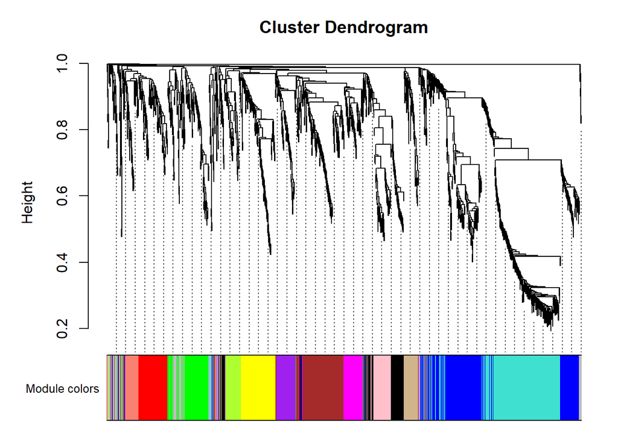

```r
# Dendograma
mergedColors = labels2colors(net$colors)

plotDendroAndColors(net$dendrograms[[1]], mergedColors[net$blockGenes[[1]]], "Module colors", dendroLabels = FALSE, hang = 0.03, addGuide = TRUE, guideHang = 0.05)
```

Ahora se intentará guardar estos grupos

```r
moduleLabels <- net$colors

moduleColors <- labels2colors(net$colors)

MEs <- net$MEs

geneTree <- net$dendrograms[[1]]


typeof(moduleLabels);head(moduleLabels)
```

```
## [1] "double"
```

```
##  ENSG00000003137.9 ENSG00000004468.13 ENSG00000004660.15 ENSG00000004776.13
##                  1                  2                  1                  6
## ENSG00000005059.16  ENSG00000005073.6
##                  7                 12
```

```r
typeof(moduleColors);head(moduleColors)
```

```
## [1] "character"
```

```
## [1] "turquoise" "blue"      "turquoise" "red"       "black"     "tan"
```

```r
typeof(MEs);#head(MEs)
```

```
## [1] "list"
```

```r
typeof(geneTree);#head(geneTree)
```

```
## [1] "list"
```

```r
# Guardar los objetos
saveRDS(moduleLabels, "moduleLabels.RDS")
saveRDS(moduleColors, "moduleColors.RDS")
saveRDS(MEs, "MEs.RDS")
saveRDS(geneTree, "geneTree.RDS")
```

## Relacionar modulos con rasgos clínicos externos

```r
MEs0 <- moduleEigengenes(mExpressionData, moduleColors)$eigengenes

MEs <- orderMEs(MEs0)

head(MEs)
```

```
##          MEblue MEturquoise       MEtan       MEred    MEsalmon MEgreenyellow
## 103  0.09140325  0.30333136 -0.11308204 -0.12081065 -0.13099562   -0.15293519
## 105  0.17189125  0.48957856 -0.11182905 -0.10992150 -0.13433647   -0.11492146
## 112 -0.06794064 -0.08482192 -0.08447662  0.03277164 -0.01427667    0.81128377
## 113  0.22628298  0.65023783 -0.16906161 -0.16271099 -0.15549112   -0.18237065
## 131 -0.05878052 -0.09037328 -0.02217593  0.09099420  0.07449078    0.05554326
## 151 -0.05485400 -0.07664442  0.02615249 -0.06000054 -0.07868080    0.18363026
##         MEblack     MEpink    MEyellow     MEgreen    MEpurple      MEbrown
## 103 -0.14065899 -0.1654663 -0.14047632 -0.13970126 -0.10219076 -0.160279102
## 105 -0.12632765 -0.1813617 -0.13153054 -0.13591235 -0.09325280 -0.136302646
## 112  0.05151013  0.1747577 -0.03693266 -0.02337464 -0.02735701 -0.007354455
## 113 -0.18227000 -0.2058847 -0.16457105 -0.16468655 -0.13602729 -0.181063204
## 131 -0.11987323 -0.1510781  0.06683604  0.81416346  0.02207201  0.028199646
## 151  0.45913784  0.2296530  0.11225371  0.07115524  0.92360095  0.221124162
##       MEmagenta      MEgrey
## 103 -0.19848783  0.06863581
## 105 -0.18407969 -0.04089987
## 112 -0.07394752 -0.11342146
## 113 -0.21987293 -0.01151214
## 131  0.30057937 -0.04850166
## 151  0.44936869  0.02050342
```

```r
moduleTraitCor <- WGCNA::cor(MEs, clinicalData, use = "p")
moduleTraitPvalue <- corPvalueStudent(moduleTraitCor, nrow(mExpressionData))
```

Representación gráfica

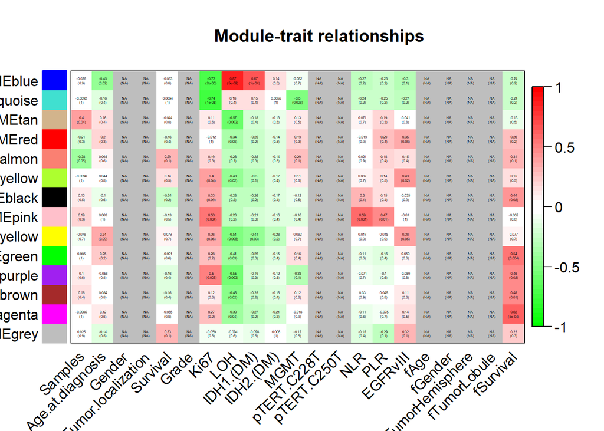

```r
textMatrix = paste0(signif(moduleTraitCor, 2), "\n(", signif(moduleTraitPvalue, 1), ")")

dim(textMatrix) = dim(moduleTraitCor)

labeledHeatmap(Matrix = moduleTraitCor, xLabels = names(clinicalData), yLabels = names(MEs), ySymbols = names(MEs), colorLabels = FALSE, colors = greenWhiteRed(50), textMatrix = textMatrix, setStdMargins = FALSE, cex.text = 0.25, zlim = c(-1, 1), main = "Module-trait relationships")
```